# Risk Factor Analysis

## Outcome Variable

**Outcome Variable:** wast_rec90d

## Predictor Variables

**Intervention Variable:** exclfeed3

**Adjustment Set:**

unadjusted

## Stratifying Variables

The analysis was stratified on these variable(s):

- agecat
- studyid
- country

## Data Summary

| agecat | studyid | country | exclfeed3 | wast_rec90d | n_cell | n |
| --- | --- | --- | --- | --- | --- | --- |
| 0-24 months | ki0047075b-MAL-ED | BANGLADESH | 0 | 0 | 10 | 118 |
| 0-24 months | ki0047075b-MAL-ED | BANGLADESH | 0 | 1 | 14 | 118 |
| 0-24 months | ki0047075b-MAL-ED | BANGLADESH | 1 | 0 | 32 | 118 |
| 0-24 months | ki0047075b-MAL-ED | BANGLADESH | 1 | 1 | 62 | 118 |
| 0-24 months | ki0047075b-MAL-ED | BRAZIL | 0 | 0 | 3 | 23 |
| 0-24 months | ki0047075b-MAL-ED | BRAZIL | 0 | 1 | 11 | 23 |
| 0-24 months | ki0047075b-MAL-ED | BRAZIL | 1 | 0 | 3 | 23 |
| 0-24 months | ki0047075b-MAL-ED | BRAZIL | 1 | 1 | 6 | 23 |
| 0-24 months | ki0047075b-MAL-ED | INDIA | 0 | 0 | 36 | 177 |
| 0-24 months | ki0047075b-MAL-ED | INDIA | 0 | 1 | 42 | 177 |
| 0-24 months | ki0047075b-MAL-ED | INDIA | 1 | 0 | 34 | 177 |
| 0-24 months | ki0047075b-MAL-ED | INDIA | 1 | 1 | 65 | 177 |
| 0-24 months | ki0047075b-MAL-ED | NEPAL | 0 | 0 | 14 | 92 |
| 0-24 months | ki0047075b-MAL-ED | NEPAL | 0 | 1 | 51 | 92 |
| 0-24 months | ki0047075b-MAL-ED | NEPAL | 1 | 0 | 6 | 92 |
| 0-24 months | ki0047075b-MAL-ED | NEPAL | 1 | 1 | 21 | 92 |
| 0-24 months | ki0047075b-MAL-ED | PERU | 0 | 0 | 4 | 32 |
| 0-24 months | ki0047075b-MAL-ED | PERU | 0 | 1 | 23 | 32 |
| 0-24 months | ki0047075b-MAL-ED | PERU | 1 | 0 | 2 | 32 |
| 0-24 months | ki0047075b-MAL-ED | PERU | 1 | 1 | 3 | 32 |
| 0-24 months | ki0047075b-MAL-ED | SOUTH AFRICA | 0 | 0 | 12 | 78 |
| 0-24 months | ki0047075b-MAL-ED | SOUTH AFRICA | 0 | 1 | 62 | 78 |
| 0-24 months | ki0047075b-MAL-ED | SOUTH AFRICA | 1 | 0 | 1 | 78 |
| 0-24 months | ki0047075b-MAL-ED | SOUTH AFRICA | 1 | 1 | 3 | 78 |
| 0-24 months | ki0047075b-MAL-ED | TANZANIA, UNITED REPUBLIC OF | 0 | 0 | 7 | 45 |
| 0-24 months | ki0047075b-MAL-ED | TANZANIA, UNITED REPUBLIC OF | 0 | 1 | 25 | 45 |
| 0-24 months | ki0047075b-MAL-ED | TANZANIA, UNITED REPUBLIC OF | 1 | 0 | 1 | 45 |
| 0-24 months | ki0047075b-MAL-ED | TANZANIA, UNITED REPUBLIC OF | 1 | 1 | 12 | 45 |
| 0-24 months | ki1000108-CMC-V-BCS-2002 | INDIA | 0 | 0 | 0 | 11 |
| 0-24 months | ki1000108-CMC-V-BCS-2002 | INDIA | 0 | 1 | 0 | 11 |

[output cut: 162 more lines]

The following strata were considered:

- agecat: 0-24 months, studyid: ki0047075b-MAL-ED, country: BANGLADESH
- agecat: 0-24 months, studyid: ki0047075b-MAL-ED, country: BRAZIL
- agecat: 0-24 months, studyid: ki0047075b-MAL-ED, country: INDIA
- agecat: 0-24 months, studyid: ki0047075b-MAL-ED, country: NEPAL
- agecat: 0-24 months, studyid: ki0047075b-MAL-ED, country: PERU
- agecat: 0-24 months, studyid: ki0047075b-MAL-ED, country: SOUTH AFRICA
- agecat: 0-24 months, studyid: ki0047075b-MAL-ED, country: TANZANIA, UNITED REPUBLIC OF
- agecat: 0-24 months, studyid: ki1000108-CMC-V-BCS-2002, country: INDIA
- agecat: 0-24 months, studyid: ki1000108-IRC, country: INDIA
- agecat: 0-24 months, studyid: ki1000109-EE, country: PAKISTAN
- agecat: 0-24 months, studyid: ki1000304b-SAS-CompFeed, country: INDIA
- agecat: 0-24 months, studyid: ki1017093b-PROVIDE, country: BANGLADESH
- agecat: 0-24 months, studyid: ki1101329-Keneba, country: GAMBIA
- agecat: 0-24 months, studyid: ki1113344-GMS-Nepal, country: NEPAL
- agecat: 0-24 months, studyid: kiGH5241-JiVitA-3, country: BANGLADESH
- agecat: 0-24 months, studyid: kiGH5241-JiVitA-4, country: BANGLADESH
- agecat: 0-6 months, studyid: ki0047075b-MAL-ED, country: BANGLADESH
- agecat: 0-6 months, studyid: ki0047075b-MAL-ED, country: BRAZIL
- agecat: 0-6 months, studyid: ki0047075b-MAL-ED, country: INDIA
- agecat: 0-6 months, studyid: ki0047075b-MAL-ED, country: NEPAL
- agecat: 0-6 months, studyid: ki0047075b-MAL-ED, country: PERU
- agecat: 0-6 months, studyid: ki0047075b-MAL-ED, country: SOUTH AFRICA
- agecat: 0-6 months, studyid: ki0047075b-MAL-ED, country: TANZANIA, UNITED REPUBLIC OF
- agecat: 0-6 months, studyid: ki1000108-CMC-V-BCS-2002, country: INDIA
- agecat: 0-6 months, studyid: ki1000108-IRC, country: INDIA
- agecat: 0-6 months, studyid: ki1000109-EE, country: PAKISTAN
- agecat: 0-6 months, studyid: ki1000304b-SAS-CompFeed, country: INDIA
- agecat: 0-6 months, studyid: ki1017093b-PROVIDE, country: BANGLADESH
- agecat: 0-6 months, studyid: ki1101329-Keneba, country: GAMBIA
- agecat: 0-6 months, studyid: ki1113344-GMS-Nepal, country: NEPAL
- agecat: 0-6 months, studyid: kiGH5241-JiVitA-3, country: BANGLADESH
- agecat: 0-6 months, studyid: kiGH5241-JiVitA-4, country: BANGLADESH
- agecat: 6-24 months, studyid: ki0047075b-MAL-ED, country: BANGLADESH
- agecat: 6-24 months, studyid: ki0047075b-MAL-ED, country: BRAZIL
- agecat: 6-24 months, studyid: ki0047075b-MAL-ED, country: INDIA
- agecat: 6-24 months, studyid: ki0047075b-MAL-ED, country: NEPAL
- agecat: 6-24 months, studyid: ki0047075b-MAL-ED, country: PERU
- agecat: 6-24 months, studyid: ki0047075b-MAL-ED, country: SOUTH AFRICA
- agecat: 6-24 months, studyid: ki0047075b-MAL-ED, country: TANZANIA, UNITED REPUBLIC OF
- agecat: 6-24 months, studyid: ki1000108-CMC-V-BCS-2002, country: INDIA
- agecat: 6-24 months, studyid: ki1000108-IRC, country: INDIA
- agecat: 6-24 months, studyid: ki1000109-EE, country: PAKISTAN
- agecat: 6-24 months, studyid: ki1000304b-SAS-CompFeed, country: INDIA
- agecat: 6-24 months, studyid: ki1017093b-PROVIDE, country: BANGLADESH
- agecat: 6-24 months, studyid: ki1101329-Keneba, country: GAMBIA
- agecat: 6-24 months, studyid: ki1113344-GMS-Nepal, country: NEPAL
- agecat: 6-24 months, studyid: kiGH5241-JiVitA-3, country: BANGLADESH
- agecat: 6-24 months, studyid: kiGH5241-JiVitA-4, country: BANGLADESH

### Dropped Strata

Some strata were dropped due to rare outcomes:

- agecat: 0-24 months, studyid: ki0047075b-MAL-ED, country: BRAZIL
- agecat: 0-24 months, studyid: ki0047075b-MAL-ED, country: PERU
- agecat: 0-24 months, studyid: ki0047075b-MAL-ED, country: SOUTH AFRICA
- agecat: 0-24 months, studyid: ki0047075b-MAL-ED, country: TANZANIA, UNITED REPUBLIC OF
- agecat: 0-24 months, studyid: ki1000108-CMC-V-BCS-2002, country: INDIA
- agecat: 0-24 months, studyid: ki1000108-IRC, country: INDIA
- agecat: 0-24 months, studyid: kiGH5241-JiVitA-4, country: BANGLADESH
- agecat: 0-6 months, studyid: ki0047075b-MAL-ED, country: BANGLADESH
- agecat: 0-6 months, studyid: ki0047075b-MAL-ED, country: BRAZIL
- agecat: 0-6 months, studyid: ki0047075b-MAL-ED, country: NEPAL
- agecat: 0-6 months, studyid: ki0047075b-MAL-ED, country: PERU
- agecat: 0-6 months, studyid: ki0047075b-MAL-ED, country: SOUTH AFRICA
- agecat: 0-6 months, studyid: ki0047075b-MAL-ED, country: TANZANIA, UNITED REPUBLIC OF
- agecat: 0-6 months, studyid: ki1000108-CMC-V-BCS-2002, country: INDIA
- agecat: 0-6 months, studyid: ki1000108-IRC, country: INDIA
- agecat: 0-6 months, studyid: ki1000109-EE, country: PAKISTAN
- agecat: 0-6 months, studyid: ki1000304b-SAS-CompFeed, country: INDIA
- agecat: 0-6 months, studyid: kiGH5241-JiVitA-4, country: BANGLADESH
- agecat: 6-24 months, studyid: ki0047075b-MAL-ED, country: BANGLADESH
- agecat: 6-24 months, studyid: ki0047075b-MAL-ED, country: BRAZIL
- agecat: 6-24 months, studyid: ki0047075b-MAL-ED, country: NEPAL
- agecat: 6-24 months, studyid: ki0047075b-MAL-ED, country: PERU
- agecat: 6-24 months, studyid: ki0047075b-MAL-ED, country: SOUTH AFRICA
- agecat: 6-24 months, studyid: ki0047075b-MAL-ED, country: TANZANIA, UNITED REPUBLIC OF
- agecat: 6-24 months, studyid: ki1000108-CMC-V-BCS-2002, country: INDIA
- agecat: 6-24 months, studyid: ki1000108-IRC, country: INDIA
- agecat: 6-24 months, studyid: ki1000109-EE, country: PAKISTAN
- agecat: 6-24 months, studyid: ki1000304b-SAS-CompFeed, country: INDIA
- agecat: 6-24 months, studyid: kiGH5241-JiVitA-3, country: BANGLADESH
- agecat: 6-24 months, studyid: kiGH5241-JiVitA-4, country: BANGLADESH

## Methods Detail

We’re interested in the causal parameters $E[Y_a]$ for all values of $a \in \mathcal{A}$. These parameters represent the mean outcome if, possibly contrary to fact, we intervened to set all units to have $A=a$. Under the randomization and positivity assumptions, these are identified by the statistical parameters $\psi_a=E_W[E_{Y|A,W}(Y|A=a,W)]$. In addition, we’re interested in the mean of $Y$, $E[Y]$ under no intervention (the observed mean). We will estimate these parameters by using SuperLearner to fit the relevant likelihood factors – $E_{Y|A,W}(Y|A=a,W)$ and $p(A=a|W)$, and then updating our likelihood fit using a joint TMLE.

For unadjusted analyses ($W=\{\}$), initial likelihoods were estimated using Lrnr_glm to estimate the simple $E(Y|A)$ and Lrnr_mean to estimate $p(A)$. For adjusted analyses, a small library containing Lrnr_glmnet, Lrnr_xgboost, and Lrnr_mean was used.

Having estimated these parameters, we will then use the delta method to estimate relative risks and attributable risks relative to a prespecified baseline level of $A$.

# Results Detail

## Results Plots

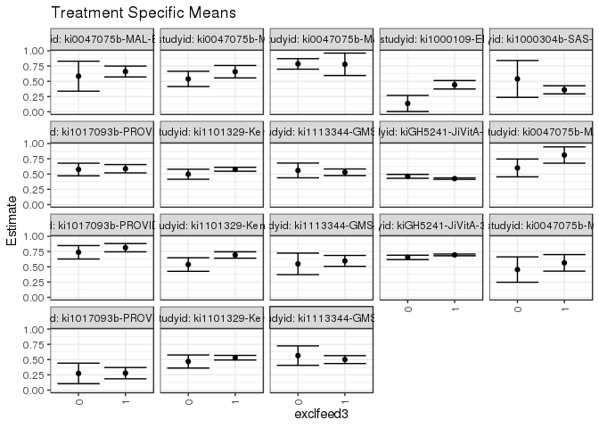

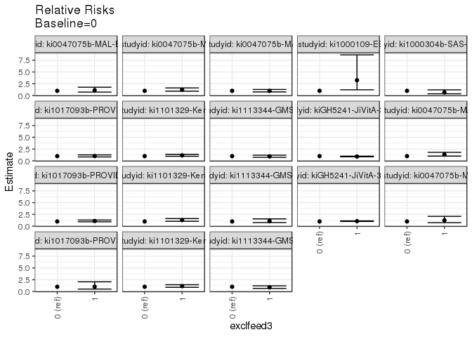

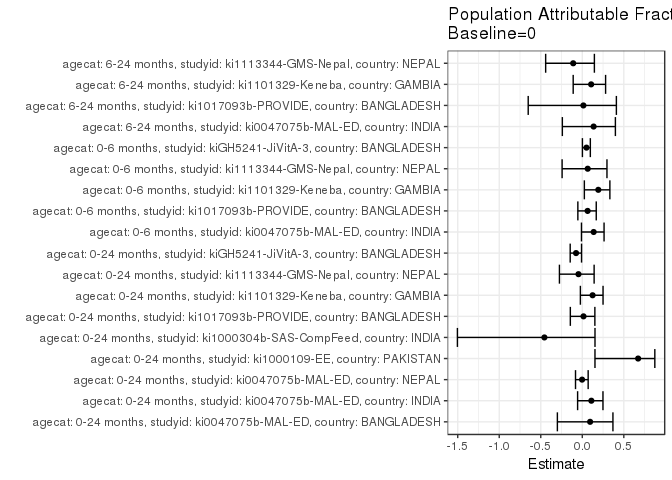

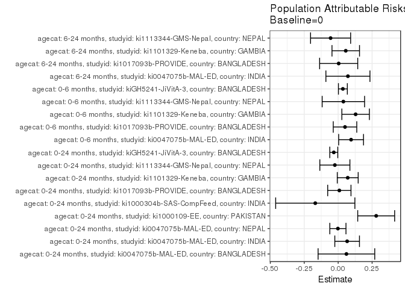

## Results Table

### Parameter: TSM

| agecat | studyid | country | intervention_level | baseline_level | estimate | ci_lower | ci_upper |
| --- | --- | --- | --- | --- | --- | --- | --- |
| 0-24 months | ki0047075b-MAL-ED | BANGLADESH | 0 | NA | 0.5833333 | 0.3380231 | 0.8286436 |
| 0-24 months | ki0047075b-MAL-ED | BANGLADESH | 1 | NA | 0.6595745 | 0.5700476 | 0.7491014 |
| 0-24 months | ki0047075b-MAL-ED | INDIA | 0 | NA | 0.5384615 | 0.4134804 | 0.6634427 |
| 0-24 months | ki0047075b-MAL-ED | INDIA | 1 | NA | 0.6565657 | 0.5545252 | 0.7586061 |
| 0-24 months | ki0047075b-MAL-ED | NEPAL | 0 | NA | 0.7846154 | 0.6984506 | 0.8707802 |
| 0-24 months | ki0047075b-MAL-ED | NEPAL | 1 | NA | 0.7777778 | 0.5946691 | 0.9608864 |
| 0-24 months | ki1000109-EE | PAKISTAN | 0 | NA | 0.1363636 | 0.0045897 | 0.2681376 |
| 0-24 months | ki1000109-EE | PAKISTAN | 1 | NA | 0.4425532 | 0.3734795 | 0.5116269 |
| 0-24 months | ki1000304b-SAS-CompFeed | INDIA | 0 | NA | 0.5384615 | 0.2364546 | 0.8404685 |
| 0-24 months | ki1000304b-SAS-CompFeed | INDIA | 1 | NA | 0.3600000 | 0.2937351 | 0.4262649 |
| 0-24 months | ki1017093b-PROVIDE | BANGLADESH | 0 | NA | 0.5744681 | 0.4715248 | 0.6774114 |
| 0-24 months | ki1017093b-PROVIDE | BANGLADESH | 1 | NA | 0.5868545 | 0.5186588 | 0.6550502 |
| 0-24 months | ki1101329-Keneba | GAMBIA | 0 | NA | 0.4968944 | 0.4144002 | 0.5793886 |
| 0-24 months | ki1101329-Keneba | GAMBIA | 1 | NA | 0.5778192 | 0.5455846 | 0.6100538 |
| 0-24 months | ki1113344-GMS-Nepal | NEPAL | 0 | NA | 0.5584416 | 0.4376550 | 0.6792281 |
| 0-24 months | ki1113344-GMS-Nepal | NEPAL | 1 | NA | 0.5292621 | 0.4753470 | 0.5831772 |
| 0-24 months | kiGH5241-JiVitA-3 | BANGLADESH | 0 | NA | 0.4621762 | 0.4306117 | 0.4937406 |
| 0-24 months | kiGH5241-JiVitA-3 | BANGLADESH | 1 | NA | 0.4249843 | 0.4128590 | 0.4371096 |
| 0-6 months | ki0047075b-MAL-ED | INDIA | 0 | NA | 0.6000000 | 0.4545320 | 0.7454680 |
| 0-6 months | ki0047075b-MAL-ED | INDIA | 1 | NA | 0.8108108 | 0.6777087 | 0.9439129 |
| 0-6 months | ki1017093b-PROVIDE | BANGLADESH | 0 | NA | 0.7377049 | 0.6278629 | 0.8475469 |
| 0-6 months | ki1017093b-PROVIDE | BANGLADESH | 1 | NA | 0.8130081 | 0.7450537 | 0.8809625 |
| 0-6 months | ki1101329-Keneba | GAMBIA | 0 | NA | 0.5373134 | 0.4257369 | 0.6488899 |
| 0-6 months | ki1101329-Keneba | GAMBIA | 1 | NA | 0.6935484 | 0.6415100 | 0.7455868 |
| 0-6 months | ki1113344-GMS-Nepal | NEPAL | 0 | NA | 0.5483871 | 0.3726315 | 0.7241427 |
| 0-6 months | ki1113344-GMS-Nepal | NEPAL | 1 | NA | 0.5966387 | 0.5078041 | 0.6854732 |
| 0-6 months | kiGH5241-JiVitA-3 | BANGLADESH | 0 | NA | 0.6539589 | 0.6182372 | 0.6896806 |
| 0-6 months | kiGH5241-JiVitA-3 | BANGLADESH | 1 | NA | 0.6947152 | 0.6802596 | 0.7091709 |
| 6-24 months | ki0047075b-MAL-ED | INDIA | 0 | NA | 0.4545455 | 0.2469787 | 0.6621122 |
| 6-24 months | ki0047075b-MAL-ED | INDIA | 1 | NA | 0.5645161 | 0.4290709 | 0.6999613 |
| 6-24 months | ki1017093b-PROVIDE | BANGLADESH | 0 | NA | 0.2727273 | 0.1045711 | 0.4408835 |
| 6-24 months | ki1017093b-PROVIDE | BANGLADESH | 1 | NA | 0.2777778 | 0.1853143 | 0.3702413 |
| 6-24 months | ki1101329-Keneba | GAMBIA | 0 | NA | 0.4680851 | 0.3606539 | 0.5755163 |
| 6-24 months | ki1101329-Keneba | GAMBIA | 1 | NA | 0.5307995 | 0.4929067 | 0.5686923 |
| 6-24 months | ki1113344-GMS-Nepal | NEPAL | 0 | NA | 0.5652174 | 0.4059418 | 0.7244930 |
| 6-24 months | ki1113344-GMS-Nepal | NEPAL | 1 | NA | 0.5000000 | 0.4354869 | 0.5645131 |

### Parameter: E(Y)

| agecat | studyid | country | intervention_level | baseline_level | estimate | ci_lower | ci_upper |
| --- | --- | --- | --- | --- | --- | --- | --- |
| 0-24 months | ki0047075b-MAL-ED | BANGLADESH | NA | NA | 0.6440678 | 0.5565826 | 0.7315530 |
| 0-24 months | ki0047075b-MAL-ED | INDIA | NA | NA | 0.6045198 | 0.5246128 | 0.6844268 |
| 0-24 months | ki0047075b-MAL-ED | NEPAL | NA | NA | 0.7826087 | 0.7016344 | 0.8635829 |
| 0-24 months | ki1000109-EE | PAKISTAN | NA | NA | 0.4163424 | 0.3511349 | 0.4815500 |
| 0-24 months | ki1000304b-SAS-CompFeed | INDIA | NA | NA | 0.3697479 | 0.3045176 | 0.4349782 |
| 0-24 months | ki1017093b-PROVIDE | BANGLADESH | NA | NA | 0.5830619 | 0.5262762 | 0.6398476 |
| 0-24 months | ki1101329-Keneba | GAMBIA | NA | NA | 0.5672609 | 0.5371792 | 0.5973426 |
| 0-24 months | ki1113344-GMS-Nepal | NEPAL | NA | NA | 0.5340426 | 0.4848509 | 0.5832342 |
| 0-24 months | kiGH5241-JiVitA-3 | BANGLADESH | NA | NA | 0.4298760 | 0.4185519 | 0.4412000 |
| 0-6 months | ki0047075b-MAL-ED | INDIA | NA | NA | 0.6951220 | 0.5922224 | 0.7980215 |
| 0-6 months | ki1017093b-PROVIDE | BANGLADESH | NA | NA | 0.7880435 | 0.7295878 | 0.8464992 |
| 0-6 months | ki1101329-Keneba | GAMBIA | NA | NA | 0.6657825 | 0.6181920 | 0.7133730 |
| 0-6 months | ki1113344-GMS-Nepal | NEPAL | NA | NA | 0.5866667 | 0.5072781 | 0.6660552 |
| 0-6 months | kiGH5241-JiVitA-3 | BANGLADESH | NA | NA | 0.6886463 | 0.6752359 | 0.7020567 |
| 6-24 months | ki0047075b-MAL-ED | INDIA | NA | NA | 0.5263158 | 0.4116286 | 0.6410029 |
| 6-24 months | ki1017093b-PROVIDE | BANGLADESH | NA | NA | 0.2764228 | 0.1950773 | 0.3577682 |
| 6-24 months | ki1101329-Keneba | GAMBIA | NA | NA | 0.5239207 | 0.4881434 | 0.5596979 |
| 6-24 months | ki1113344-GMS-Nepal | NEPAL | NA | NA | 0.5093750 | 0.4496016 | 0.5691484 |

### Parameter: RR

| agecat | studyid | country | intervention_level | baseline_level | estimate | ci_lower | ci_upper |
| --- | --- | --- | --- | --- | --- | --- | --- |
| 0-24 months | ki0047075b-MAL-ED | BANGLADESH | 0 | 0 | 1.0000000 | 1.0000000 | 1.000000 |
| 0-24 months | ki0047075b-MAL-ED | BANGLADESH | 1 | 0 | 1.1306991 | 0.7266508 | 1.759415 |
| 0-24 months | ki0047075b-MAL-ED | INDIA | 0 | 0 | 1.0000000 | 1.0000000 | 1.000000 |
| 0-24 months | ki0047075b-MAL-ED | INDIA | 1 | 0 | 1.2193362 | 0.9221737 | 1.612257 |
| 0-24 months | ki0047075b-MAL-ED | NEPAL | 0 | 0 | 1.0000000 | 1.0000000 | 1.000000 |
| 0-24 months | ki0047075b-MAL-ED | NEPAL | 1 | 0 | 0.9912854 | 0.7640468 | 1.286108 |
| 0-24 months | ki1000109-EE | PAKISTAN | 0 | 0 | 1.0000000 | 1.0000000 | 1.000000 |
| 0-24 months | ki1000109-EE | PAKISTAN | 1 | 0 | 3.2453901 | 1.2192841 | 8.638312 |
| 0-24 months | ki1000304b-SAS-CompFeed | INDIA | 0 | 0 | 1.0000000 | 1.0000000 | 1.000000 |
| 0-24 months | ki1000304b-SAS-CompFeed | INDIA | 1 | 0 | 0.6685714 | 0.3704954 | 1.206460 |
| 0-24 months | ki1017093b-PROVIDE | BANGLADESH | 0 | 0 | 1.0000000 | 1.0000000 | 1.000000 |
| 0-24 months | ki1017093b-PROVIDE | BANGLADESH | 1 | 0 | 1.0215615 | 0.8249554 | 1.265023 |
| 0-24 months | ki1101329-Keneba | GAMBIA | 0 | 0 | 1.0000000 | 1.0000000 | 1.000000 |
| 0-24 months | ki1101329-Keneba | GAMBIA | 1 | 0 | 1.1628611 | 0.9760291 | 1.385457 |
| 0-24 months | ki1113344-GMS-Nepal | NEPAL | 0 | 0 | 1.0000000 | 1.0000000 | 1.000000 |
| 0-24 months | ki1113344-GMS-Nepal | NEPAL | 1 | 0 | 0.9477484 | 0.7461299 | 1.203848 |
| 0-24 months | kiGH5241-JiVitA-3 | BANGLADESH | 0 | 0 | 1.0000000 | 1.0000000 | 1.000000 |
| 0-24 months | kiGH5241-JiVitA-3 | BANGLADESH | 1 | 0 | 0.9195288 | 0.8539274 | 0.990170 |
| 0-6 months | ki0047075b-MAL-ED | INDIA | 0 | 0 | 1.0000000 | 1.0000000 | 1.000000 |
| 0-6 months | ki0047075b-MAL-ED | INDIA | 1 | 0 | 1.3513514 | 1.0083141 | 1.811093 |
| 0-6 months | ki1017093b-PROVIDE | BANGLADESH | 0 | 0 | 1.0000000 | 1.0000000 | 1.000000 |
| 0-6 months | ki1017093b-PROVIDE | BANGLADESH | 1 | 0 | 1.1020777 | 0.9290804 | 1.307288 |
| 0-6 months | ki1101329-Keneba | GAMBIA | 0 | 0 | 1.0000000 | 1.0000000 | 1.000000 |
| 0-6 months | ki1101329-Keneba | GAMBIA | 1 | 0 | 1.2907706 | 1.0350448 | 1.609678 |
| 0-6 months | ki1113344-GMS-Nepal | NEPAL | 0 | 0 | 1.0000000 | 1.0000000 | 1.000000 |
| 0-6 months | ki1113344-GMS-Nepal | NEPAL | 1 | 0 | 1.0879881 | 0.7640980 | 1.549171 |
| 0-6 months | kiGH5241-JiVitA-3 | BANGLADESH | 0 | 0 | 1.0000000 | 1.0000000 | 1.000000 |
| 0-6 months | kiGH5241-JiVitA-3 | BANGLADESH | 1 | 0 | 1.0623224 | 1.0020067 | 1.126269 |
| 6-24 months | ki0047075b-MAL-ED | INDIA | 0 | 0 | 1.0000000 | 1.0000000 | 1.000000 |
| 6-24 months | ki0047075b-MAL-ED | INDIA | 1 | 0 | 1.2419355 | 0.7414375 | 2.080288 |
| 6-24 months | ki1017093b-PROVIDE | BANGLADESH | 0 | 0 | 1.0000000 | 1.0000000 | 1.000000 |
| 6-24 months | ki1017093b-PROVIDE | BANGLADESH | 1 | 0 | 1.0185185 | 0.5056188 | 2.051704 |
| 6-24 months | ki1101329-Keneba | GAMBIA | 0 | 0 | 1.0000000 | 1.0000000 | 1.000000 |
| 6-24 months | ki1101329-Keneba | GAMBIA | 1 | 0 | 1.1339807 | 0.8916667 | 1.442144 |
| 6-24 months | ki1113344-GMS-Nepal | NEPAL | 0 | 0 | 1.0000000 | 1.0000000 | 1.000000 |
| 6-24 months | ki1113344-GMS-Nepal | NEPAL | 1 | 0 | 0.8846154 | 0.6486774 | 1.206369 |

### Parameter: PAR

| agecat | studyid | country | intervention_level | baseline_level | estimate | ci_lower | ci_upper |
| --- | --- | --- | --- | --- | --- | --- | --- |
| 0-24 months | ki0047075b-MAL-ED | BANGLADESH | 0 | NA | 0.0607345 | -0.1479020 | 0.2693709 |
| 0-24 months | ki0047075b-MAL-ED | INDIA | 0 | NA | 0.0660582 | -0.0247619 | 0.1568784 |
| 0-24 months | ki0047075b-MAL-ED | NEPAL | 0 | NA | -0.0020067 | -0.0614602 | 0.0574468 |
| 0-24 months | ki1000109-EE | PAKISTAN | 0 | NA | 0.2799788 | 0.1439670 | 0.4159905 |
| 0-24 months | ki1000304b-SAS-CompFeed | INDIA | 0 | NA | -0.1687136 | -0.4604384 | 0.1230111 |
| 0-24 months | ki1017093b-PROVIDE | BANGLADESH | 0 | NA | 0.0085938 | -0.0772171 | 0.0944047 |
| 0-24 months | ki1101329-Keneba | GAMBIA | 0 | NA | 0.0703665 | -0.0066378 | 0.1473708 |
| 0-24 months | ki1113344-GMS-Nepal | NEPAL | 0 | NA | -0.0243990 | -0.1351746 | 0.0863766 |
| 0-24 months | kiGH5241-JiVitA-3 | BANGLADESH | 0 | NA | -0.0323002 | -0.0616672 | -0.0029332 |
| 0-6 months | ki0047075b-MAL-ED | INDIA | 0 | NA | 0.0951220 | 0.0036396 | 0.1866043 |
| 0-6 months | ki1017093b-PROVIDE | BANGLADESH | 0 | NA | 0.0503386 | -0.0362157 | 0.1368928 |
| 0-6 months | ki1101329-Keneba | GAMBIA | 0 | NA | 0.1284691 | 0.0270718 | 0.2298663 |
| 0-6 months | ki1113344-GMS-Nepal | NEPAL | 0 | NA | 0.0382796 | -0.1179078 | 0.1944669 |
| 0-6 months | kiGH5241-JiVitA-3 | BANGLADESH | 0 | NA | 0.0346873 | 0.0018872 | 0.0674875 |
| 6-24 months | ki0047075b-MAL-ED | INDIA | 0 | NA | 0.0717703 | -0.0904685 | 0.2340092 |
| 6-24 months | ki1017093b-PROVIDE | BANGLADESH | 0 | NA | 0.0036955 | -0.1366586 | 0.1440496 |
| 6-24 months | ki1101329-Keneba | GAMBIA | 0 | NA | 0.0558355 | -0.0455270 | 0.1571980 |
| 6-24 months | ki1113344-GMS-Nepal | NEPAL | 0 | NA | -0.0558424 | -0.2034345 | 0.0917498 |

### Parameter: PAF

| agecat | studyid | country | intervention_level | baseline_level | estimate | ci_lower | ci_upper |
| --- | --- | --- | --- | --- | --- | --- | --- |
| 0-24 months | ki0047075b-MAL-ED | BANGLADESH | 0 | NA | 0.0942982 | -0.2999968 | 0.3690018 |
| 0-24 months | ki0047075b-MAL-ED | INDIA | 0 | NA | 0.1092739 | -0.0563498 | 0.2489297 |
| 0-24 months | ki0047075b-MAL-ED | NEPAL | 0 | NA | -0.0025641 | -0.0815646 | 0.0706659 |
| 0-24 months | ki1000109-EE | PAKISTAN | 0 | NA | 0.6724724 | 0.1526889 | 0.8733944 |
| 0-24 months | ki1000304b-SAS-CompFeed | INDIA | 0 | NA | -0.4562937 | -1.5037815 | 0.1529647 |
| 0-24 months | ki1017093b-PROVIDE | BANGLADESH | 0 | NA | 0.0147391 | -0.1440037 | 0.1514547 |
| 0-24 months | ki1101329-Keneba | GAMBIA | 0 | NA | 0.1240461 | -0.0229225 | 0.2498990 |
| 0-24 months | ki1113344-GMS-Nepal | NEPAL | 0 | NA | -0.0456874 | -0.2752195 | 0.1425303 |
| 0-24 months | kiGH5241-JiVitA-3 | BANGLADESH | 0 | NA | -0.0751384 | -0.1456832 | -0.0089374 |
| 0-6 months | ki0047075b-MAL-ED | INDIA | 0 | NA | 0.1368421 | -0.0098481 | 0.2622241 |
| 0-6 months | ki1017093b-PROVIDE | BANGLADESH | 0 | NA | 0.0638779 | -0.0533814 | 0.1680843 |
| 0-6 months | ki1101329-Keneba | GAMBIA | 0 | NA | 0.1929595 | 0.0247570 | 0.3321517 |
| 0-6 months | ki1113344-GMS-Nepal | NEPAL | 0 | NA | 0.0652493 | -0.2430486 | 0.2970839 |
| 0-6 months | kiGH5241-JiVitA-3 | BANGLADESH | 0 | NA | 0.0503703 | 0.0014912 | 0.0968567 |
| 6-24 months | ki0047075b-MAL-ED | INDIA | 0 | NA | 0.1363636 | -0.2402126 | 0.3985969 |
| 6-24 months | ki1017093b-PROVIDE | BANGLADESH | 0 | NA | 0.0133690 | -0.6512460 | 0.4104811 |
| 6-24 months | ki1101329-Keneba | GAMBIA | 0 | NA | 0.1065725 | -0.1095957 | 0.2806275 |
| 6-24 months | ki1113344-GMS-Nepal | NEPAL | 0 | NA | -0.1096292 | -0.4410898 | 0.1455931 |